# RNA-Seq Analysis

# PCA plot

## PCA summarizing the sample-level variance within the data set

PCA plots of RNA-seq data show the characteristics of samples according to gene expression.Each dot indicates a sample. PCA uses linear commbination of the gene expression values to definr a new set of unreleated variables. It helps in reduce the dimensions of a data set.

```r
# we have to normalize the dds object before ploting PCA plot by using  variance stabilizing transformation(vst) function
dds_norm <- vst(dds,blind = FALSE)

dds_norm
```

```
## class: DESeqTransform
## dim: 33063 7
## metadata(1): version
## assays(1): ''
## rownames(33063): ENSG00000000003.14 ENSG00000000419.12 ...
##   ENSG00000283697.1 ENSG00000283698.1
## rowData names(22): baseMean baseVar ... maxCooks dispFit
## colnames(7): SRR579382 SRR579383 ... SRR579387 SRR579513
## colData names(3): condition Treatment sizeFactor
```

```r
# We first have to save the results of the `plotPCA()` function for use with `ggplot2`
pca_results <-
  plotPCA(
    dds_norm,
    intgroup = c("condition"),
    returnData = TRUE # This argument tells R to return the PCA values
  )
```

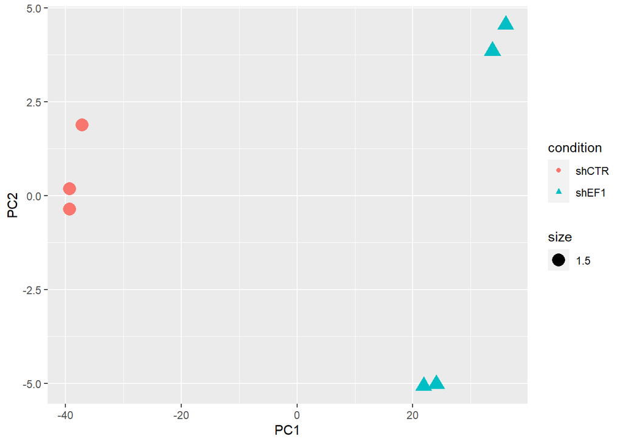

```r
# Plot using `ggplot()` function and save to an object
annotated_pca_plot<-ggplot(
  pca_results,
  aes(
    x = PC1,
    y = PC2,
    # plot points with different colors for each `condition` group
    shape=condition,
    color= condition,
    size = 1.5
    # plot points with different shapes for each `condition` group
  )
) +
  # Make a scatter plot
  geom_point()

# display annotated plot
annotated_pca_plot
```

# MA plot

MA plots are a common way to visualize the results of a differential analysis.It showing the relationship between mean count and log2 fold change.

```r
MAplot <- plotMA(res,ylim=c(-2,2),main ="MA Plot",returnData = TRUE)
```

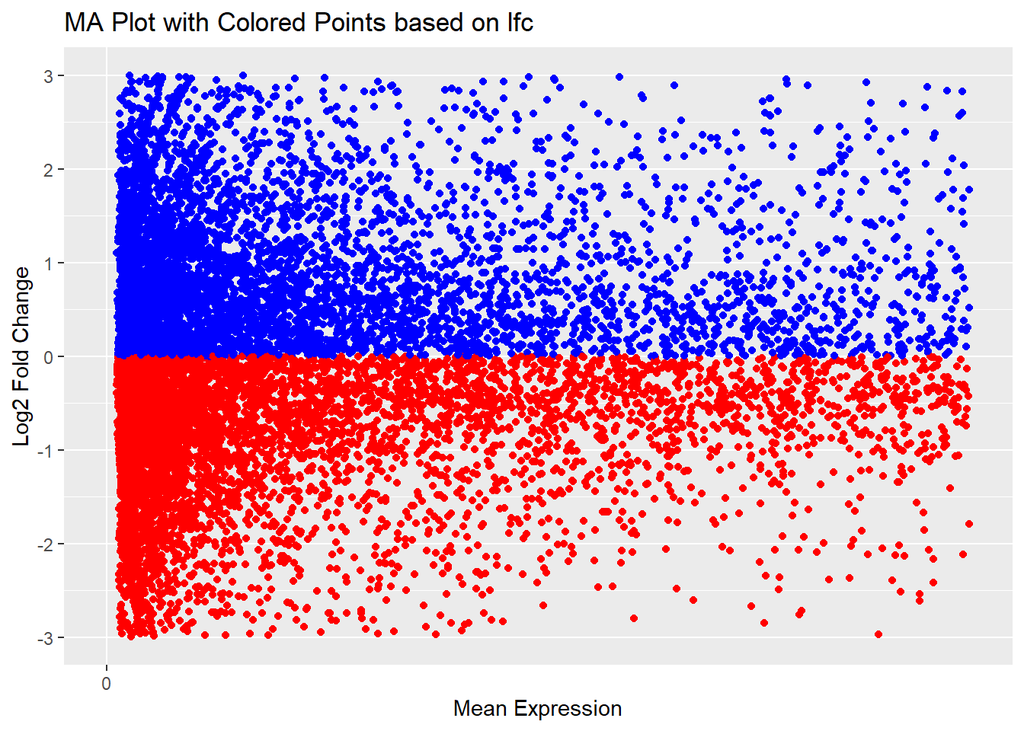

```r
MAplot$lfc_category <- ifelse(MAplot$lfc < 0, "red",
                              ifelse(MAplot$lfc == 0, "black", "blue"))

MA_color <- MAplot$lfc_category

ggplot(MAplot,aes(x=mean,y=lfc))+
   geom_point(color = MA_color) +
  xlab("Mean Expression") +
  ylab("Log2 Fold Change") +
  ggtitle("MA Plot with Colored Points based on lfc")+
  scale_x_continuous(limits = c(0, 1000), breaks = seq(0, 40000, by = 40000)) +
  scale_y_continuous(limits = c(-3, 3), breaks = seq(-3, 3, by = 1))
```

#Alternative shrinkage estimators The shrunken log fold changes are useful for ranking and visualization, without the need for arbitrary filters on low count genes.

```r
resultsNames(dds)
```

```
## [1] "Intercept"                "condition_shEF1_vs_shCTR"
```

```r
resLFC <- lfcShrink(dds, coef="condition_shEF1_vs_shCTR", type="apeglm")
```

```
## using 'apeglm' for LFC shrinkage. If used in published research, please cite:
##     Zhu, A., Ibrahim, J.G., Love, M.I. (2018) Heavy-tailed prior distributions for
##     sequence count data: removing the noise and preserving large differences.
##     Bioinformatics. https://doi.org/10.1093/bioinformatics/bty895
```

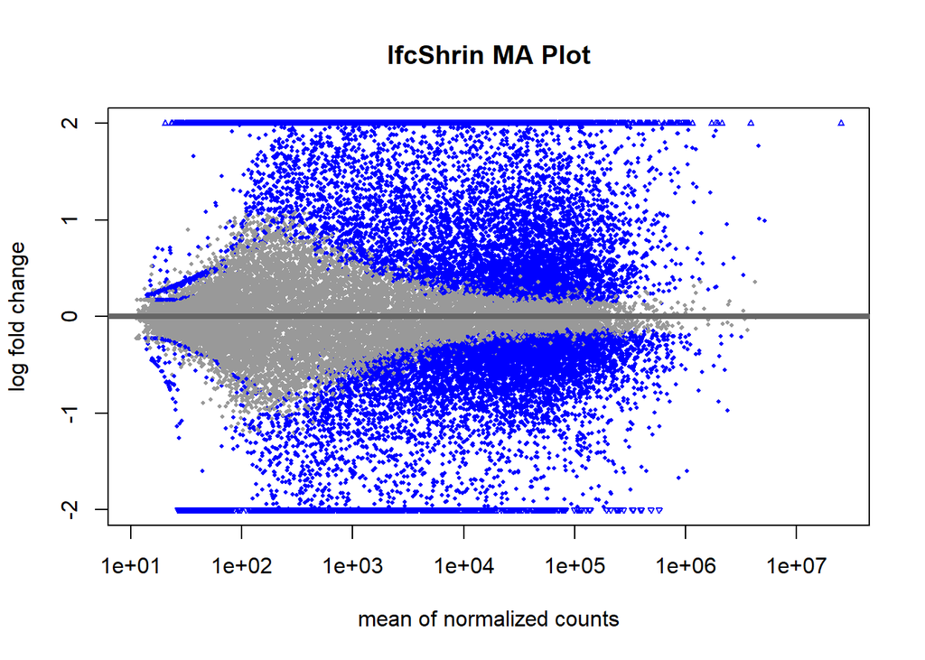

```r
plotMA(resLFC,ylim=c(-2,2), main ="lfcShrin MA Plot" )
```

# Volcano plot

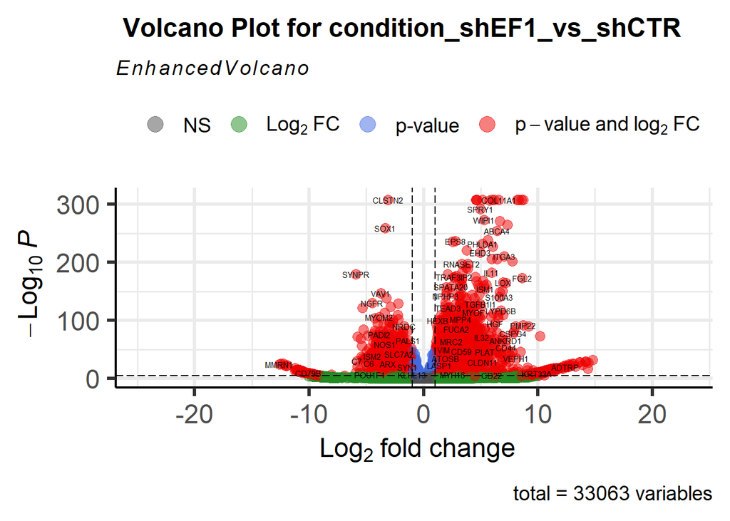

```r
EnhancedVolcano(si_gene,
                lab = si_gene$gene_id,
                x = 'log2FoldChange',
                y = 'pvalue',title = ' Volcano Plot for condition_shEF1_vs_shCTR',labSize = 2, pointSize = 3.0)
```

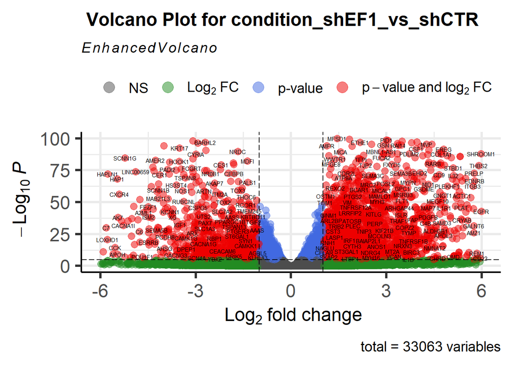

```r
EnhancedVolcano(si_gene,
                lab = si_gene$gene_id,
                x = 'log2FoldChange',
                y = 'pvalue',title = ' Volcano Plot for condition_shEF1_vs_shCTR',
                ylim = c(0,100),
                labSize = 2, pointSize = 3.0,xlim = c(-6,6))
```

#Pheatmap

# `pheatmap` for upregulated genes

```r
upregular1 <- si_gene %>%
  mutate(gene_expression = si_gene$log2FoldChange >0.1 & si_gene$padj <0.05)%>%
  filter(gene_expression == TRUE) %>%
  arrange(desc(.$padj)) %>%
  distinct(gene_id, .keep_all = TRUE)%>%
  drop_na(gene_id) %>%
  .[1:10,]

upregular1
```

```
##                     baseMean log2FoldChange      lfcSE     stat     pvalue
## ENSG00000197386 154063.56915      0.2277798 0.09927352 2.294467 0.02176367
## ENSG00000157578   1474.96509      0.5757143 0.25088536 2.294730 0.02174858
## ENSG00000272138     29.70328      8.1248941 3.53953134 2.295472 0.02170610
## ENSG00000248672    628.41332      1.1075692 0.48249224 2.295517 0.02170351
## ENSG00000200278    682.59961      1.4185933 0.61762856 2.296839 0.02162797
## ENSG00000215869    490.23682      0.8211147 0.35727597 2.298264 0.02154674
## ENSG00000186787   2556.61956      0.4383332 0.19059202 2.299851 0.02145668
## ENSG00000198121  40331.43556      0.3146702 0.13674238 2.301190 0.02138090
## ENSG00000240160     65.70432      3.0650936 1.33181768 2.301436 0.02136698
## ENSG00000169193   8103.65570      0.3482913 0.15132859 2.301556 0.02136020
##                       padj      gene_id            version         ENSEMBL
## ENSG00000197386 0.04978764          HTT ENSG00000197386.10 ENSG00000197386
## ENSG00000157578 0.04975668        LCA5L ENSG00000157578.13 ENSG00000157578
## ENSG00000272138 0.04967017    LINC01607  ENSG00000272138.1 ENSG00000272138
## ENSG00000248672 0.04966779   LY75-CD302  ENSG00000248672.5 ENSG00000248672
## ENSG00000200278 0.04950911    RNA5SP352  ENSG00000200278.1 ENSG00000200278
## ENSG00000215869 0.04933379 LOC100129138  ENSG00000215869.4 ENSG00000215869
## ENSG00000186787 0.04914874       SPIN2B  ENSG00000186787.8 ENSG00000186787
## ENSG00000198121 0.04899271        LPAR1 ENSG00000198121.13 ENSG00000198121
## ENSG00000240160 0.04896434    RN7SL263P  ENSG00000240160.3 ENSG00000240160
## ENSG00000169193 0.04895524      CCDC126 ENSG00000169193.11 ENSG00000169193
##                 gene_expression
## ENSG00000197386            TRUE
## ENSG00000157578            TRUE
## ENSG00000272138            TRUE
## ENSG00000248672            TRUE
## ENSG00000200278            TRUE
## ENSG00000215869            TRUE
## ENSG00000186787            TRUE
## ENSG00000198121            TRUE
## ENSG00000240160            TRUE
## ENSG00000169193            TRUE
```

```r
dds_2 <-dds
rownames(dds_2 )<- si_gene$ENSEMBL
dds_2
```

```
## class: DESeqDataSet
## dim: 33063 7
## metadata(1): version
## assays(4): counts mu H cooks
## rownames(33063): ENSG00000000003 ENSG00000000419 ... ENSG00000283697
##   ENSG00000283698
## rowData names(22): baseMean baseVar ... deviance maxCooks
## colnames(7): SRR579382 SRR579383 ... SRR579387 SRR579513
## colData names(3): condition Treatment sizeFactor
```

```r
rownames(upregular1)
```

```
##  [1] "ENSG00000197386" "ENSG00000157578" "ENSG00000272138" "ENSG00000248672"
##  [5] "ENSG00000200278" "ENSG00000215869" "ENSG00000186787" "ENSG00000198121"
##  [9] "ENSG00000240160" "ENSG00000169193"
```

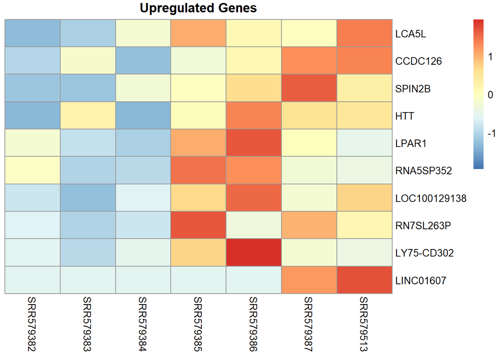

```r
nr_counts <- counts(dds_2,normalized = T)[rownames(upregular1),]
nr_counts2 <- t(apply(nr_counts,1,scale))
colnames(nr_counts2) <- rownames(condition_data)


up_genes <- merge(nr_counts2,upregular1$gene_id, by = 0) %>%
  `rownames<-`(.$y)%>%
  select(2:8)

pheatmap(up_genes,scale = 'row',main = "Upregulated Genes",cluster_rows = F,cluster_cols = F )
```

# `pheatmap` for downregulated genes

```r
downregular1 <- si_gene %>%
  mutate(gene_expression = si_gene$log2FoldChange < 0.1 & si_gene$padj <0.05)%>%
  filter(gene_expression == TRUE) %>%
  arrange(.$padj) %>%
  distinct(gene_id, .keep_all = TRUE)%>%
  drop_na(gene_id) %>%
  .[1:10,]

downregular1
```

```
##                  baseMean log2FoldChange      lfcSE      stat        pvalue
## ENSG00000158258  60792.82      -3.131337 0.08031118 -38.99005  0.000000e+00
## ENSG00000182968  24654.32      -3.354953 0.09746162 -34.42333 1.129048e-259
## ENSG00000163630  23046.45      -5.898585 0.20584572 -28.65537 1.374171e-180
## ENSG00000141968  23016.73      -3.747838 0.14492551 -25.86045 1.856444e-147
## ENSG00000166501 195031.74      -3.254703 0.12937886 -25.15638 1.203444e-139
## ENSG00000064300  80150.53      -4.486174 0.18444226 -24.32292 1.121807e-130
## ENSG00000157214  50702.88      -2.211140 0.09119948 -24.24510 7.448103e-130
## ENSG00000105369  11525.27      -5.359210 0.22811667 -23.49328 4.777365e-122
## ENSG00000079101  12233.33      -3.411276 0.15021448 -22.70937 3.619904e-114
## ENSG00000196730 255855.15      -2.269950 0.10155829 -22.35120 1.175431e-110
##                          padj gene_id            version         ENSEMBL
## ENSG00000158258  0.000000e+00  CLSTN2 ENSG00000158258.16 ENSG00000158258
## ENSG00000182968 2.002869e-256    SOX1  ENSG00000182968.4 ENSG00000182968
## ENSG00000163630 1.185909e-177   SYNPR ENSG00000163630.10 ENSG00000163630
## ENSG00000141968 9.119709e-145    VAV1  ENSG00000141968.7 ENSG00000141968
## ENSG00000166501 5.123621e-137   PRKCB ENSG00000166501.12 ENSG00000166501
## ENSG00000064300 4.592362e-128    NGFR  ENSG00000064300.8 ENSG00000064300
## ENSG00000157214 2.972817e-127  STEAP2 ENSG00000157214.13 ENSG00000157214
## ENSG00000105369 1.540869e-119   CD79A  ENSG00000105369.9 ENSG00000105369
## ENSG00000079101 1.060433e-111   CLUL1 ENSG00000079101.16 ENSG00000079101
## ENSG00000196730 3.292342e-108   DAPK1 ENSG00000196730.12 ENSG00000196730
##                 gene_expression
## ENSG00000158258            TRUE
## ENSG00000182968            TRUE
## ENSG00000163630            TRUE
## ENSG00000141968            TRUE
## ENSG00000166501            TRUE
## ENSG00000064300            TRUE
## ENSG00000157214            TRUE
## ENSG00000105369            TRUE
## ENSG00000079101            TRUE
## ENSG00000196730            TRUE
```

```r
# renaming the rownames of  DESeq object
dds_2 <-dds
rownames(dds_2 )<- si_gene$ENSEMBL
dds_2
```

```
## class: DESeqDataSet
## dim: 33063 7
## metadata(1): version
## assays(4): counts mu H cooks
## rownames(33063): ENSG00000000003 ENSG00000000419 ... ENSG00000283697
##   ENSG00000283698
## rowData names(22): baseMean baseVar ... deviance maxCooks
## colnames(7): SRR579382 SRR579383 ... SRR579387 SRR579513
## colData names(3): condition Treatment sizeFactor
```

```r
rownames(downregular1)
```

```
##  [1] "ENSG00000158258" "ENSG00000182968" "ENSG00000163630" "ENSG00000141968"
##  [5] "ENSG00000166501" "ENSG00000064300" "ENSG00000157214" "ENSG00000105369"
##  [9] "ENSG00000079101" "ENSG00000196730"
```

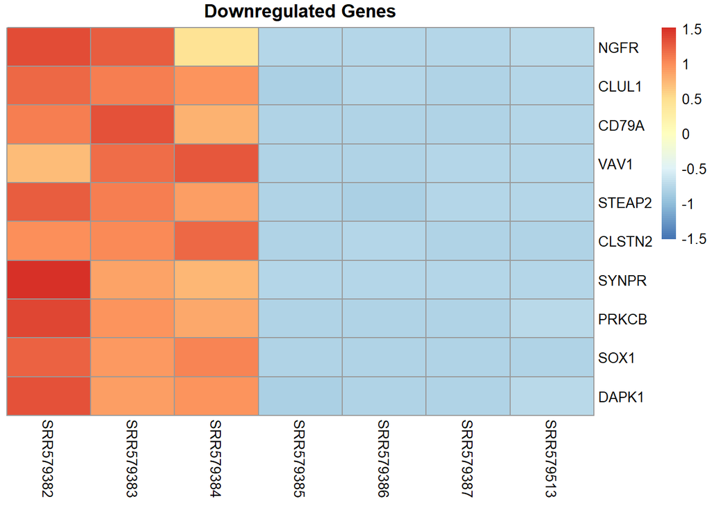

```r
nr_counts <- counts(dds_2,normalized = T)[rownames(downregular1),]
nr_counts2 <- t(apply(nr_counts,1,scale))
colnames(nr_counts2) <- rownames(condition_data)


down_genes <- merge(nr_counts2,downregular1$gene_id, by = 0) %>%
  `rownames<-`(.$y)%>%
  select(2:8)

pheatmap(down_genes,scale = 'row',main = "Downregulated Genes",cluster_rows = F,cluster_cols = F )
```

# preprocessing the data for Gene Enrichment Analysis

```r
EA <- data.frame(log2FoldChange = si_gene$log2FoldChange,gene_id =  si_gene$gene_id,ENSEMBL= si_gene$ENSEMBL) %>%
  `rownames<-`(.$ENSEMBL_ids) %>%
  .[!duplicated(.[c("gene_id")]),] %>%
  na.omit(.) %>%
  `rownames<-`(.$gene_id)

all(rownames(EA)) %in% all(EA$gene_id)
```

```
## [1] TRUE
```

# creating a vector for the `a_gene for the function`gseGO`

```r
a_gene <- c("log2FoldChange" = EA[, 1])
names(a_gene) <- EA[,2]
a_gene <-sort(a_gene,decreasing = TRUE)

head(a_gene) %>%
  head() %>%
  kable()%>%
  kable_styling(bootstrap_options = "bordered")
```

|  | x |
| --- | --- |
| LRP2 | 21.39715 |
| LINC00994 | 21.26684 |
| DISC1-IT1 | 21.17971 |
| HECW2-AS1 | 20.89517 |
| RN7SL510P | 20.89517 |
| ACY3 | 20.73632 |

# `Keytypes` for the humandatabase

```r
keytypes(org.Hs.eg.db)
```

```
##  [1] "ACCNUM"       "ALIAS"        "ENSEMBL"      "ENSEMBLPROT"  "ENSEMBLTRANS"
##  [6] "ENTREZID"     "ENZYME"       "EVIDENCE"     "EVIDENCEALL"  "GENENAME"
## [11] "GENETYPE"     "GO"           "GOALL"        "IPI"          "MAP"
## [16] "OMIM"         "ONTOLOGY"     "ONTOLOGYALL"  "PATH"         "PFAM"
## [21] "PMID"         "PROSITE"      "REFSEQ"       "SYMBOL"       "UCSCKG"
## [26] "UNIPROT"
```

# Gene Set Enrichment

```r
gse <- gseGO(geneList=a_gene,
             ont = "ALL",
             keyType =  "SYMBOL",
             nPerm = 10000,
             minGSSize = 3,
             maxGSSize = 1000,
             pvalueCutoff = 0.05,
             verbose = TRUE,
             OrgDb = org.Hs.eg.db,
             pAdjustMethod = "none")
```

```
## preparing geneSet collections...
```

```
## GSEA analysis...
```

```
## leading edge analysis...
```

```
## done...
```

```r
summary(gse)%>%
  head() %>%
  kable()%>%
  kable_styling(bootstrap_options = "bordered")
```

|  | ONTOLOGY | ID | Description | setSize | enrichmentScore | NES | pvalue | p.adjust | qvalue | rank | leading_edge | core_enrichment |
| --- | --- | --- | --- | --- | --- | --- | --- | --- | --- | --- | --- | --- |
| GO:0051241 | BP | GO:0051241 | negative regulation of multicellular organismal process | 996 | 0.4815479 | 1.491182 | 0.0001005 | 0.0001005 | 0.0142474 | 3759 | tags=31%, list=17%, signal=27% | PF4/SOX17/ADRB2/WNT7A/ADTRP/SLC2A10/TLR4/TIE1/PSG9/CD34/MEOX…… |
| GO:0040012 | BP | GO:0040012 | regulation of locomotion | 958 | 0.5054796 | 1.564260 | 0.0001006 | 0.0001006 | 0.0142474 | 3871 | tags=33%, list=17%, signal=29% | PTPRT/CSF2/FGFBP1/WNT7A/CCL5/ADTRP/TLR4/TIE1/TF/AIRE/MEOX2/M…… |
| GO:0009887 | BP | GO:0009887 | animal organ morphogenesis | 948 | 0.4822909 | 1.491985 | 0.0001006 | 0.0001006 | 0.0142474 | 3518 | tags=27%, list=16%, signal=24% | LRP2/ASB2/SOX17/TBX2/WNT7A/CD34/MYO7A/WNT7B/TACSTD2/PRDM1/RB…… |
| GO:2000145 | BP | GO:2000145 | regulation of cell motility | 920 | 0.5078649 | 1.570466 | 0.0001007 | 0.0001007 | 0.0142474 | 3871 | tags=33%, list=17%, signal=29% | PTPRT/CSF2/FGFBP1/WNT7A/CCL5/ADTRP/TLR4/TIE1/TF/AIRE/MEOX2/M…… |
| GO:0032101 | BP | GO:0032101 | regulation of response to external stimulus | 912 | 0.4627075 | 1.430631 | 0.0001007 | 0.0001007 | 0.0142474 | 4612 | tags=35%, list=21%, signal=29% | MYOD1/TRIM15/CCL5/ADTRP/TLR4/CD34/NLRP10/CLEC12B/FABP4/LGALS…… |
| GO:0060548 | BP | GO:0060548 | negative regulation of cell death | 912 | 0.4325863 | 1.337500 | 0.0001007 | 0.0001007 | 0.0142474 | 3878 | tags=24%, list=17%, signal=21% | LRP2/PF4/CSF2/WNT7A/CCL5/CD34/MYOCD/MAG/CRYAA/CDSN/PPARGC1A/…… |

# Dotplot

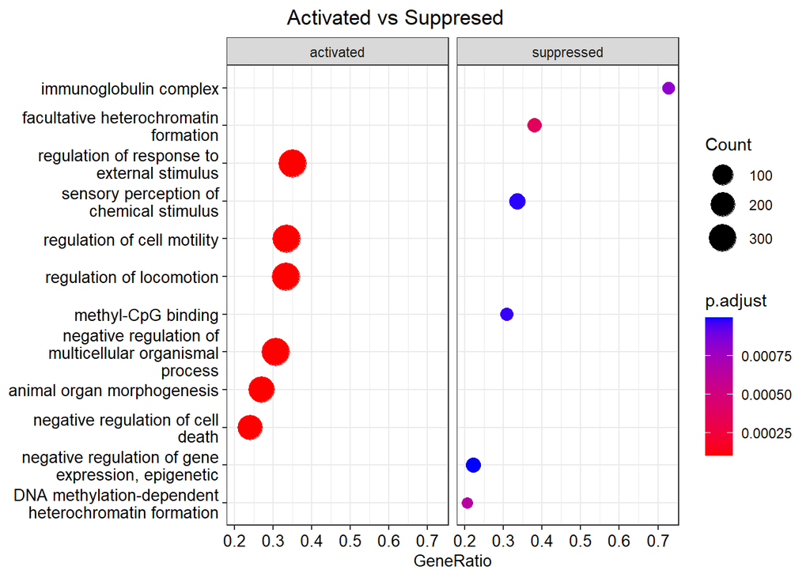

```r
dotplot(gse,showCategory=6, title = "          Activated vs Suppresed ",
        font.size = 10,
        label_format = 30,
        split=".sign")+facet_grid(.~.sign)
```

# cnetplot

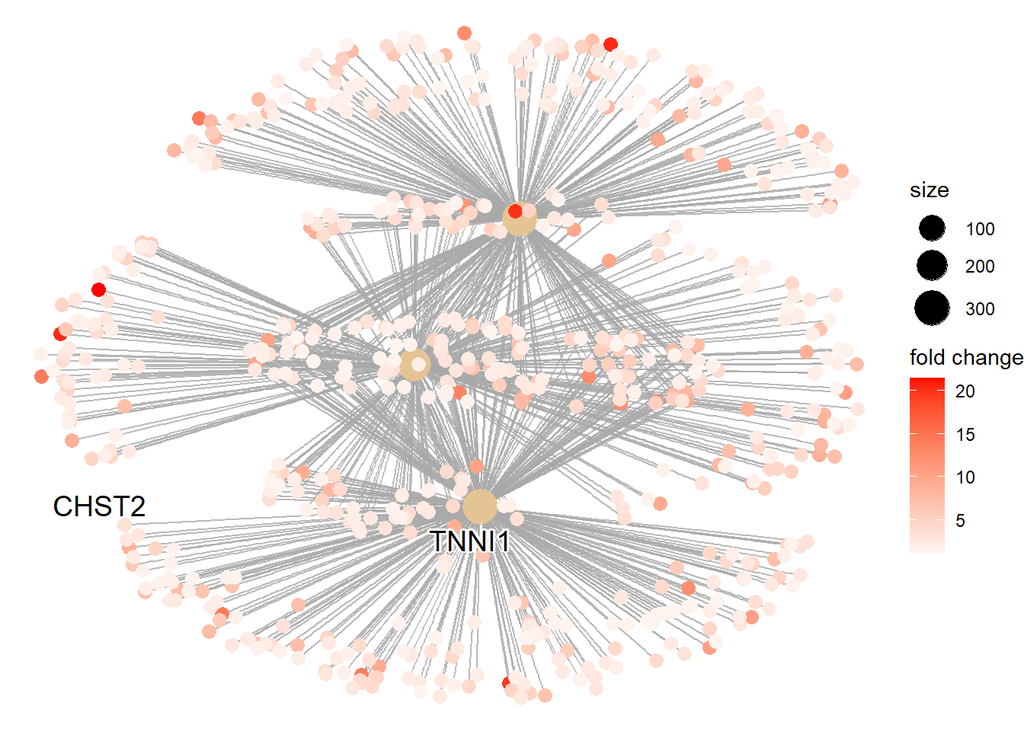

```r
# categorySize can be either 'pvalue' or 'geneNum'

cnetplot(gse, categorySize="pvalue", foldChange=a_gene, showCategory = 3,node_label = "all")
```

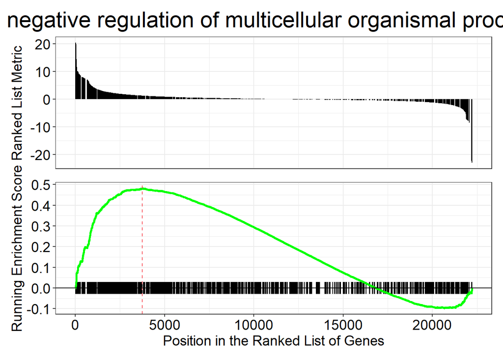

```r
#ridgeplot(gse) + labs(x = "enrichment distribution")

gseaplot(gse, by = "all", title = gse$Description[1], geneSetID = 1)
```

# GSE with KEGG pathway

```r
keytypes(org.Hs.eg.db)
```

```
##  [1] "ACCNUM"       "ALIAS"        "ENSEMBL"      "ENSEMBLPROT"  "ENSEMBLTRANS"
##  [6] "ENTREZID"     "ENZYME"       "EVIDENCE"     "EVIDENCEALL"  "GENENAME"
## [11] "GENETYPE"     "GO"           "GOALL"        "IPI"          "MAP"
## [16] "OMIM"         "ONTOLOGY"     "ONTOLOGYALL"  "PATH"         "PFAM"
## [21] "PMID"         "PROSITE"      "REFSEQ"       "SYMBOL"       "UCSCKG"
## [26] "UNIPROT"
```

```r
# creating a vector e for th e gene enrichment analysis with KEGG

b<- EA %>%
  add_column(Uniprot = 0)%>%
  mutate(Uniprot = mapIds(org.Hs.eg.db, keys = rownames(EA), keytype = "SYMBOL", column = "UNIPROT")) %>%
  distinct(Uniprot, .keep_all = TRUE)%>%
  drop_na(Uniprot)%>%
  `rownames<-`(.$Uniprot) %>%
  select(log2FoldChange)
head(b)%>%
  head() %>%
  kable()%>%
  kable_styling(bootstrap_options = "bordered")
```

|  | log2FoldChange |
| --- | --- |
| A0A024RCI0 | -0.6443001 |
| O60762 | -0.1804732 |
| Q8IZE3 | -0.0618177 |
| A0A024R922 | -0.7508539 |
| P09769 | -7.4623373 |
| A0A024R962 | 0.8117653 |

```r
#creating a vector

b_gene <- c("log2FoldChange" = b[, 1])
names(b_gene) <- rownames(b)
b_gene <-sort(b_gene,decreasing = TRUE)
head(b_gene) %>%
  head() %>%
  kable()%>%
  kable_styling(bootstrap_options = "bordered")
```

|  | x |
| --- | --- |
| P98164 | 21.39715 |
| A0A024R5L2 | 20.73632 |
| Q86YL5 | 20.72518 |
| Q8WYK0 | 20.62831 |
| Q9NQM4 | 20.33242 |
| A0A024R6E7 | 20.33242 |

```r
# passing the vector e  to gseKEGG for gene enrichment analysis
kk2 <- gseKEGG(geneList     = b_gene,
               organism     = "hsa",
               nPerm        = 10000,
               minGSSize    = 3,
               maxGSSize    =  22000 ,
               pvalueCutoff = 0.05,
               pAdjustMethod = "none",
               keyType       = 'uniprot')
```

```
## Reading KEGG annotation online: "https://rest.kegg.jp/link/hsa/pathway"...
```

```
## Reading KEGG annotation online: "https://rest.kegg.jp/list/pathway/hsa"...
```

```
## Reading KEGG annotation online: "https://rest.kegg.jp/conv/uniprot/hsa"...
```

```
## preparing geneSet collections...
```

```
## GSEA analysis...
```

```
## leading edge analysis...
```

```
## done...
```

link to (KEGG link)[https://learn.gencore.bio.nyu.edu/rna-seq-analysis/gene-set-enrichment-analysis/]

```r
summary(kk2) %>%
  head() %>%
  kable()%>%
  kable_styling(bootstrap_options = "bordered")
```

|  | ID | Description | setSize | enrichmentScore | NES | pvalue | p.adjust | qvalue | rank | leading_edge | core_enrichment |
| --- | --- | --- | --- | --- | --- | --- | --- | --- | --- | --- | --- |
| hsa05200 | hsa05200 | Pathways in cancer | 430 | 0.4915739 | 1.494257 | 0.0001028 | 0.0001028 | 0.0066504 | 2487 | tags=25%, list=15%, signal=22% | O00755/P56706/P49767/P30556/A0A140VJK4/Q8NBG6/P15509/Q5TA89/…… |
| hsa05165 | hsa05165 | Human papillomavirus infection | 279 | 0.5269005 | 1.569846 | 0.0001063 | 0.0001063 | 0.0066504 | 3207 | tags=32%, list=19%, signal=26% | O00755/P56706/O00587/Q5TA89/P04628/P07996/Q9H1J7/A0A140VJM0/…… |
| hsa04060 | hsa04060 | Cytokine-cytokine receptor interaction | 198 | 0.6337457 | 1.844621 | 0.0001102 | 0.0001102 | 0.0066504 | 2736 | tags=53%, list=17%, signal=44% | P02776/P04141/D0EI67/Q07325/O95150/O00300/P15509/Q9NPH9/P505…… |
| hsa04510 | hsa04510 | Focal adhesion | 174 | 0.6058900 | 1.747229 | 0.0001117 | 0.0001117 | 0.0066504 | 3277 | tags=47%, list=20%, signal=38% | P49767/P07996/A0A140VJM0/P04085/B3KTN6/P14210/Q504U8/P35442/…… |
| hsa05205 | hsa05205 | Proteoglycans in cancer | 167 | 0.5910359 | 1.698458 | 0.0001120 | 0.0001120 | 0.0066504 | 2001 | tags=28%, list=12%, signal=24% | O00755/O00206/P56706/P04628/P07996/Q9H1J7/P16070/P18827/P142…… |
| hsa04668 | hsa04668 | TNF signaling pathway | 101 | 0.6584243 | 1.805610 | 0.0002380 | 0.0002380 | 0.0081852 | 2808 | tags=47%, list=17%, signal=39% | P04141/D0EI67/P49767/P05305/Q13478/P09341/P05362/P15018/B2RA…… |